# The GWAS pipeline

#### Inverse-normal transformed residuals

The script *transform_phenotypes_INT* calculates the inverse-normal transformed residuals that result from the first step of “fully adjusted two-stage inverse-normal transformation” ([reference](https://journals.plos.org/plosone/article/file?id=10.1371/journal.pone.0233847&type=printable)).  
These residuals can then be used as dependent variable in a regression on the genotype and the covariates, as done in the script *gwas_diagnose_INT*.

The steps performed are:

- Linear regression of the phenotype against the covariates (no genotype included)
- Extraction of the residuals from that regression
- Inverse Normal transformation of the residuals

Input are the phenotype file, the covariate file, and a string defining the covariates to be used in the linear regression. Multiple phenotypes can be transformed simutaneously.

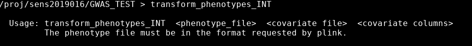

**Example**:

```
cd /proj/sens2019016/GWAS_TEST
covarnames = "PC1,PC2,PC3,PC4,PC5,PC6,PC7,PC8,PC9,PC10,array,sex,age"
transform_phenotypes_INT  liver_fat_ext.txt  GWAS_covariates.txt ${covarnames}
```

Output:

- the tranformed file (*IN_transformed_liver_fat_ext.txt*)
- a plot showing the original distributions of the penotype, the distribution of the residuals after the linear regression, the distribution of the residuals after the linear regression and inverse-normal transformation, and a QQ-plot of the latter (as PDF)

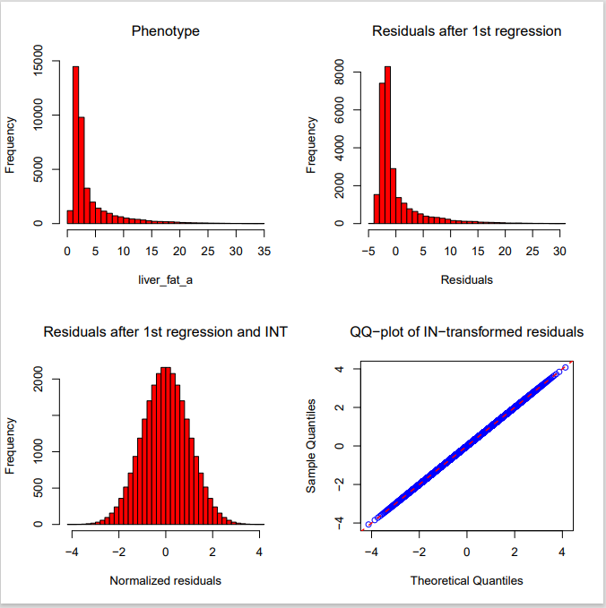

### Explore correlations between covariates

The script *examine_covariates*

- calculates correlations between pairs of covariates and plots a heatmap illustrating this
- calculates the variance inflation factors for the covariates

The script has one mandatory parameter (*covariate-file*) and one optional parameter (*correlation threshold*). The threshold defines the Pearson correlation that is regarded as maximum permissible. The default value of the threshold is 0.5.

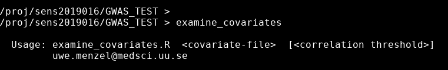

**Example**:

```
cd /proj/sens2019016/GWAS_TEST
examine_covariates  GWAS_covx.txt
```

Output:

- a spreadsheet (*examine_covariates.xls*) listing pairs of covariates whose correlation exceeds the threshold
- a heatmap of the correlation between the covariates (*correlation_heatmap.png*)

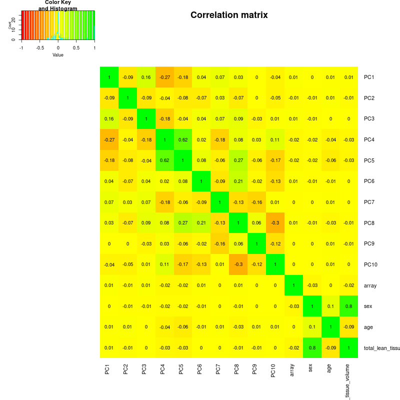

### Fetching phenotypes from a local database

An ID is necessary to fetch a phenotype from the database. Therefore, it is convenient to use *fetch_pheno* together with *search_fieldID*. The latter script provides the ID.

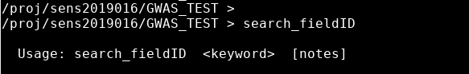

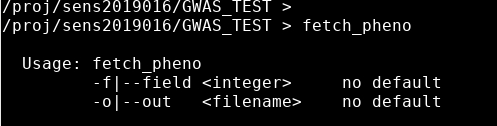

The local database is specified in *~/fetch_settings.sh*.

**Example**:

```
cd /proj/sens2019016/GWAS_TEST
search_fieldID principal
search_fieldID principal notes # if the "Question asked" is to be added to the output
```

This command yields two fields containing the keyword *principal*. One of the field ID’s can now be used to fetch the corresponding phenotype:

```
fetch_pheno --field 22009 --out PCA.txt
```

The output file *PCA.txt* now contains 40 principal components (plus the *IID* and *FID* columns).

### Filtering phenotype files

In order to filter phenotype files, a file containing the ID’s to be filtered for is necessary. Two alternative programs can be used for filtering.

1.) A bash script:

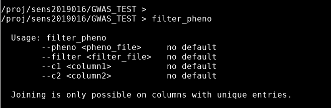

2.) An R-script:

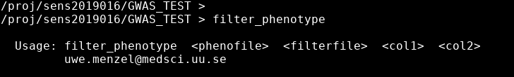

Both scripts use the same input parameters:

- the phenotype file to be filtered
- the filter file, containg sample ID’s
- the ID-column number in the phenotype file (mostly 1)
- the ID-column number in the filter file (mostly 1)

**Examples**:

The file *caucasian_22006.txt* contains Caucasian individuals only and can be used as a filter file. (The file was fetched from a local database using fetch_pheno.) The phenotype file *pheno_487409.txt* contains additional samples. We attempt to filter that phenotype file for Caucasians:

```
cd /proj/sens2019016/GWAS_TEST
wc -l pheno_487409.txt     # 487410
wc -l caucasian_22006.txt  # 409630  less samples
filter_pheno --pheno pheno_487409.txt --filter caucasian_22006.txt --c1 1 --c2 1
```

We tell the script in which columns the ID’s reside by specifying *- -c1* and *- -c2*, respectively.  
The output phenotype file *pheno_487409.filtered* contains only Caucasian individuals.

The same can be achieved by using the R-script:

```
filter_phenotype  pheno_487409.txt  caucasian_22006.txt  1  1
```

The R-script returns an output file (*pheno_487409.txt.filtered*) containing the filtered phenotype and a Venn diagram illustrating the intersection of the input files and the output file:

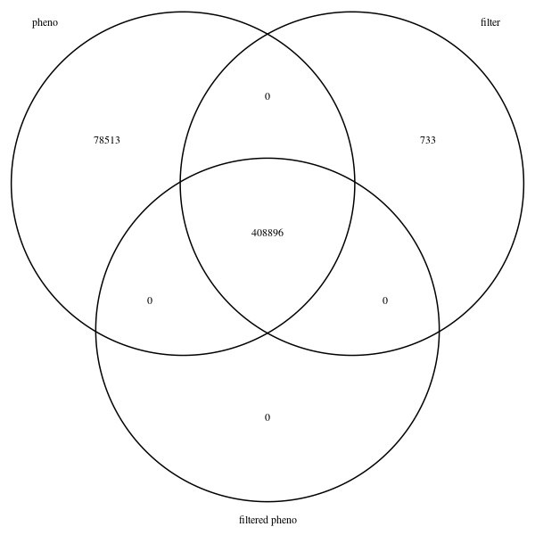

Note that the output (filtered) file might contain fewer lines than both input files because the intersection of samples is considered (as illustrated by the Venn diagramm).

### Extract genotype data in raw format (extract counts)

Raw genotype files can be read by external programs, e.g. by R. In order to extract genetic raw data for a given list of markers and samples, the script *extract_raw* can be used.

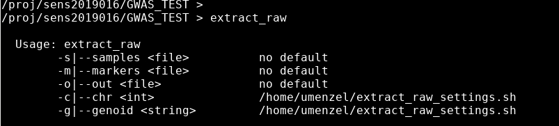

Mandatory parameters are:

- the name of the file containing the samples to be included (*- -samples*)
- the name of the file containing the markers to be included (*- -markers*)
- a string defining the file name prefix for the output files (*- -out*)

Optional parameters are:

- the chromosomes to be considered (*- -chr*), with default “1-22”
- the ID of the genotype database to extract from (*- -genoid*), with default “ukb_imp_v3” (the most comprehensive database)

The optional parameters are inferred from *~/extract_raw_settings.sh* if not specified on the command line.

**Example**:

The script should be run in interactive mode (otherwise, the script complains and exits!).

```
interactive -n 16 -t 30:00 -A sens2019016
cd /proj/sens2019016/GWAS_TEST
wc -l SNP_list.txt    # 10 markers
wc -l samples.txtx    # 337466 samples
extract_raw --samples samples.txt --markers SNP_list.txt  --out SNP_out
```

The output consists of a logfile and a file containing the raw data for each chromosome that harbored at least one of the specified markers. For the example above, hits have been found on chromosomes 1, 2, 3, 4, 6, 8, 10, 15, and 19 :

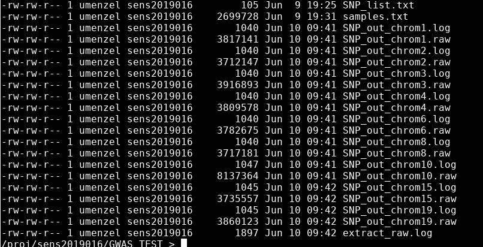

It might be a problem to obtain the sample list (which possibly must be filtered). Here we show how the samples filtered for ethnic background and relatives can be created. In order to do this, we use the sample list belonging to the “FTD” database:

```
cd /proj/sens2019016/GENOTYPES/PGEN_ORIG                    # go there
cp -i ../PGEN/FTD_chr9.psam /proj/sens2019016/GWAS_TEST/    # copy to workfolder
cd /proj/sens2019016/GWAS_TEST/                             # go back to workfolder
tail -n +2 FTD_chr9.psam | awk '{print $2}' > samples.txt   # create list
wc -l samples.txt                                           # 337466 that's the list used above
```

Please, do not change or move the original file /proj/sens2019016/GENOTYPES/PGEN_ORIG/FTD_chr9.psam !

### Merge multiple file by ID’s in the 1st column

The script can be used to merge multiple files, e.g. the output files of extract_raw. The files will be merged based on the entries in the first column of the input files (should be some sort of unique ID’s). The files to be merged have to be specified using a file of file names (fofn):

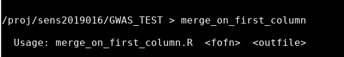

**Example**:

```
cd /proj/sens2019016/GWAS_TEST/
ls tab1_chrom*.raw > raw.fofn    # create fofn
merge_on_first_column  raw.fofn  merged.out
```

The output file (here: *merged.out*) contains the concatenated files.

### Calculate linkage of a pair of SNP’s

The linkage of a pair of markers can be calculated using *linkage_pair*

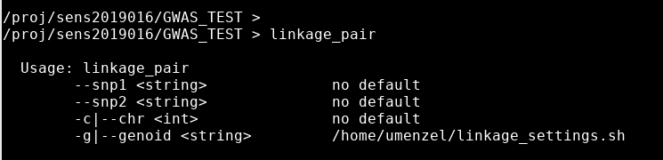

Optional parameter:

- the data base to fetch the genotype data from (*- -genoid*)

If not provided on the command line, the name of the genotype data base will be taken from *~/linkage_settings.sh*.

Like many programs described here, *linkage_pair* consists of a bash script (*linkage_pair.sh*), an R script (*linkage_pair.R*), and an Rmarkdown file (*linkage_pair.Rmd*). The bash script downloads the marker genotype, the R script does the calculations, and the Rmarkdown presents the results. Addtionally, the script *extract_genotype.sh* is utilized. The script simply runs a regression of the genotype of one marker against the other.

**Example**:

```
cd /proj/sens2019016/GWAS_TEST/
linkage_pair --snp1 rs58542926_T_C --snp2 rs188247550_T_C  --chr 19
```

More example output:

- \Gold\Personal folders and scripts\Uwe\gwas\sens2019016\LINKAGE
- \Gold\MolEpi\MolEpic\Imiomics\gwas\sens2019016\LINKAGE

### Filter a (phenotype) file

It is often necessary to filter the samples in a phenotype (or other) file according to certain criteria. This can be accomplished by using *filter_samples*. The script uses the ID column for filtering.

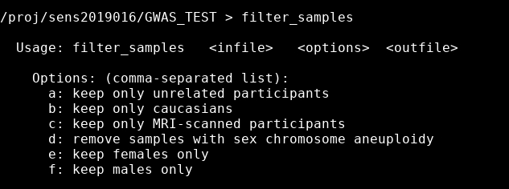

The options can be combined using a comma-separated list. The scripts can read several input formats, but the files must be tab-separated.

**Examples**:

PGEN format (*.psam*):

```
cd /proj/sens2019016/GWAS_TEST/
filter_samples ukb_imp_v3_chr19.psam a,b  filtered.txt              # keep only unrelated Caucasians
filter_samples ukb_imp_v3_chr19.psam a,b,c,d  filtered2.txt         # keep only unrelated Caucasians that are MRI scanned and do not have aneuploidy
filter_samples ukb_imp_v3_chr19.psam a,b,c,d,e  filtered_female.txt # as above but females only
filter_samples ukb_imp_v3_chr19.psam a,b,c,d,f  filtered_male.txt   # as above but males only
```

BED format (*.fam*):

```
cd /proj/sens2019016/GWAS_TEST/
filter_samples  FTD_chr22.fam  a filtered_relat.txt   # keep only unrelated individuals
```

RAW files with 2 columns:

```
cd /proj/sens2019016/GWAS_TEST/
filter_samples  filter_input.txt  c,f  filter_output_1.txt   # keep only MRI-scanned males
```

RAW files with 1 column:

```
cd /proj/sens2019016/GWAS_TEST/
filter_samples  filter_in_one.txt  c,e  filter_output_2.txt  # keep only MRI-scanned females
```

The script should automatically detect the input file format (PGEN, BED, RAW).

### Join two phenotype files

This program can only be run in an interactive session (not in the login node, checked by the script). To start an interactive session, type for example:

```
interactive -n 16 -t 30:00 -A sens2019016
```

The script can then be started:

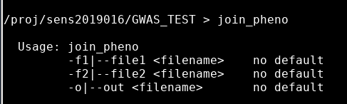

The scripts merges the two input phenotype files (specified by *- -file1* and *- -file2*, respectively) into one. The two files are merged by the *IID* column, the concatenated file is written to the file specified by *- -out*.

**Example**:

```
cd /proj/sens2019016/GWAS_TEST
join_pheno --file1 BMI_21001_plink.txt --file2 IN_transformed_BMI_21001_plink.txt --out joined_phenofile.txt.
```

For illustration, a Venn plot is made showing the number of intersecting samples of both files:

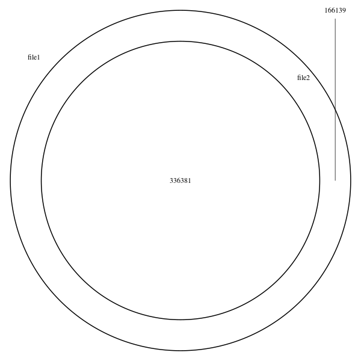

(Here, the *file2* samples are a true subset of the " *file 1* samples.)

### Get basic genotype statistics for a list of markers

The command *get_stats* calculates some basic genotype statistics for a number of markers. The only command line parameter is the name of the file containing the (unique) marker names:

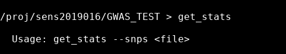

The script is very fast and can also be run in the login node. Some default parameters are fetched from *~/stats_settings.sh*, e.g. the chromosomes to search for the specified markers (default is “1-22”). The output includes two files:

- one with basic frequency statistics for each marker (*.afreq*), and
- one with some metrics connected to Hardy-Weinberg equilibrium (*.hardy*).

**Example**:

```
cd /proj/sens2019016/GWAS_TEST
get_stats --snps snp_list.txt
```

### Fetch samples from a list randomly

It might be necessary to fetch a certain number of samples randomly from a bigger list. As an example, the reference genotype dataset used for *GCTA-COJO* consists of 10.000 randomly chosen samples, in order to save CPU time. The script *random_samples* can fetch from lists in different formats (*.pgen*, *.bed*, or raw files with 1 or two columns). The input file format is automatically detected.

The command line parameters are:

- the (big) input file,
- the number of random samples to fetch, and
- the name of the output file:

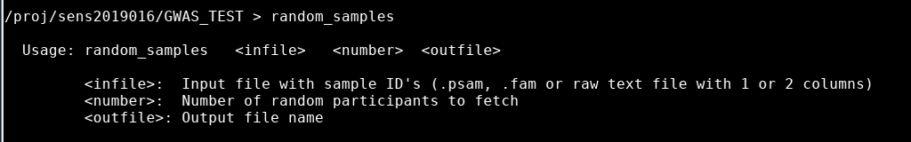

**Examples**:

```
cd /proj/sens2019016/GWAS_TEST
random_samples ukb_imp_v3_chr19.psam  10000  sampled.txt   # from .pgen
random_samples  FTD_chr22.fam  50000 s50000.txt            # from .bed
random_samples  filter_input.txt  1000  s1000.txt          # from raw file with 2 columns
random_samples  filter_in_one.txt  10000  choose10000.txt  # from raw file with one column
```

### Remove samples from a genotype database

Sometimes samples have to be removed from a genotype database, for instance when patients withdraw from a study. This task can be accomplished using *remove_samples*.

Input is:

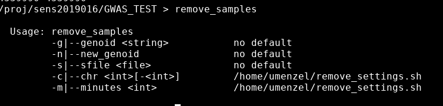

Optional parameters are:

- the chromosomes to involve (*- -chr*) and
- the estimated runtime in minutes (*- -minutes*).

If the optional parameters are not invoked on the command line, they are taken from *~/remove_settings.sh*.

The sample file (*- -sfile*) must be a space/tab-delimited text file with family IDs in the first column and individual IDs in the second column, as usual for *PLINK*. The script should work for *.pgen* and *.bed* genotype formats, the format is automatically detected.

**Example**:

```
cd /proj/sens2019016/GWAS_TEST
remove_samples --genoid MF2 --new_genoid MF3 --sfile samples_to_remove.txt
```

One batch job for each chromosome is started simultaneously.

### Allele info

The script *get_alleles* just displays some information about a marker, taken from the local (“ukb_imp_v3”) database. Output looks like that:

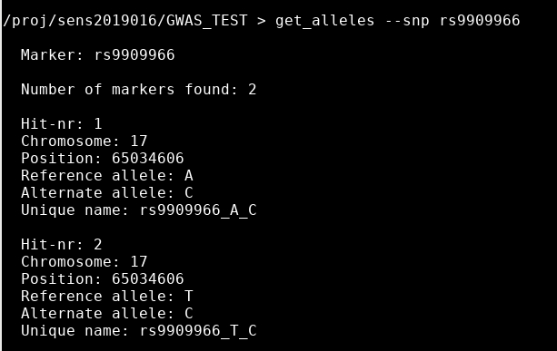

### Other programs

The following programs are mainly for administrative purposes and are not described in detail. Typing the program name on the command line provides some help (as for all scripts). The source code of the scripts is comprehensively commented.

The scripts are:

- *extract_snps* : Create a smaller genotype database (with less markers) from a bigger one
- *extract_samples* : Create a smaller genotype database (with less samples) from a bigger one
- *show_logdates* : Show the modification dates of all logfiles in the current folder and compares with the date info of some other specified file
- *convert_genotype*: converts a genotype database from *.pgen* to *.bed* format (which is for example needed for PLINK clump)
- *convert_phenofile*: converts phenotype files (delivered by Taro) to a format readable by *PLINK*
- *concat_gwas_results*: Merges GWAS output files (“*.linear”) for all chromosomes. Needed for Mendelian Randomization.
- *merge_gwas_results*: the same as *concat_gwas_results*, with a little bit different code

uwe.menzel@medsci.uu.se  
uwe.menzel@matstat.org